# FEH statistical analysis

## Introduction

This quick guide provides an overview of the core FEH functions that can be used to generate extreme flow estimates from single-site or pooling (gauged & ungauged) approaches. It is assumed that the reader has knowledge of the theory of these approaches; this guide is intended to demonstrate how to use the UKFE package rather than to explain the FEH statistical method.

The following table provides the key functions for implementing the FEH methods.

| Function | Purpose |
| --- | --- |
| GetCDs/CDsXML | Get catchment descriptors using the NRFA gauge reference number or import them from XML files downloaded from the FEH Web Service |
| GetAM/AMImport | Get annual maximum data from sites suitable for pooling or from AM files |
| QuickResults | Provides default pooling results (gauged, ungauged & fake ungauged), directly from catchment descriptors |
| QMED | Estimates QMED from catchment descriptors with donor options (either donor IDs or a number of donors - which are then automatically chosen based on distance) |
| DonAdj | Provides a list of donor candidates based on proximity to the study catchment |
| Pool | Creates a pooling group with the option of excluding one or more sites |
| H2 | The heterogeneity measure for pooling groups |
| DiagPlots | Provides a number of diagnostic plots to compare the sites in a pooling group |
| Zdists | The Zdist statistic to determine the distribution with the best fit to the pooling group |
| PoolEst | Flood estimates from the pooling group |
| Uncertainty | Quantifies uncertainty for gauged (enhanced single-site) and ungauged pooling groups |
| GenLog/GEV/GenPareto/Gumbel/Kappa3 | Four functions for each distribution to fit the distribution and obtain flood frequency estimates and growth factors |
| POTextract or POTt | Functions for extracting peaks over threshold data |
| AnnualStat | Extract annual statistics. The default is maximum, but any statistic can be used such as sum or mean. |

We need to load the package before we can use any of the functions:

```r
library(UKFE)
```

## Overview and assumptions of the FEH statistical method

This section provides a brief overview of the FEH statistical method, and its core assumptions. Examples of how to apply the method can be found later.

The FEH statistical method comes under the broader term of ‘regional frequency analysis’ and employs the “index flood” procedure for estimating peak flows at a single location on a river line. The procedure has two main steps, which are multiplied together for a final result:

- Estimate the index flood (in the FEH method, the index flood is QMED - the median annual maximum flow).
- Calculate the growth curve: This provides growth factors as a function of return period and is a standardised model of the AMAX distribution. In this case a growth factor is the extreme flow of interestd (such as the 100-year flow) divided by QMED.

Multiplying the index flood by the growth curve scales the standardised growth factor to produce the flow estimate for the catchment of interest. When the catchment is gauged, the index flood is estimated as the median of the observed annual maximum sample (assuming suitable data quality). When the catchment is ungauged, the index flood is estimated using a multiple regression equation, using catchment descriptors as predictors.

The growth curve is estimated by pooling gauged data from catchments which are similar to the catchment of interest. A statistical distribution is assumed. Then, weighted average parameters of the fitted distribution (L-moment ratios) from the AMAX samples in the pooling group are used to estimate the growth curve.

There are numerous choices and possible adjustments which can be made for each step. The UKFE package, in general, provides default settings with no adjustments; however, these can be changed by the user.

There are several key underlying assumptions in FEH statistical analysis. As stated in Hosking and Wallis (1997), the index-flood procedure makes the following assumptions:

- Observations at any given site are identically distributed.
- Observations at any given site are serially independent.
- Observations at different sites are independent.
- Frequency distributions at different sites are identical apart from a scale factor.
- The mathematical form of the regional growth curve is correctly specified.

The first of these leads to the assumption of stationarity (i.e. observations of past flood events are assumed to represent the behaviour of future events). Where this is not the case, non-stationary methods can be applied. For example, non-stationary distributions can be fitted using other software such as the `nonstat` R package (Hecht and Zitzmann, 2025).

The QMED regression equation was calibrated using an approach similar to the generalised least squares method. This allows for covariance of the model residuals (errors). Firstly, the observed QMEDs (on which it was calibrated) were logarithmically transformed. The catchment descriptors used were also transformed. With this in mind, the assumptions of the QMED equation are as follows:

- The relationship between the transformed independent variables (predictors) and the logarithmically transformed dependent variable (QMED) is linear.
- Observations (observed QMEDs used in calibration) are independent of each other.
- Model and sampling errors are independent of each other.
- Model and sampling errors are normally distributed and have a mean of zero.
- Predictor variables are independent.
- The cross-correlation of model errors can be described by the distance between catchment centroids, and the form of the associated correlation matrix is known for the calibration process.

## Getting catchment descriptors

One of the first steps in any FEH analysis is to obtain catchment descriptors (CDs). See the ‘Data input’ article for information on functions for importing CDs.

## Quick results

First, we’ll obtain some CDs for site 55002 and then apply the QuickResults function. The results from the default analysis at gauge 55002 are printed to the console. This is a list with three elements. The first is a data frame with the following columns: return period (RP), peak flow estimates (Q) and growth factor estimates (GF). The second element is the estimated L-CV and L-skew (linear coefficients of variation and skewness). The third element provides distribution parameters (location, scale, and shape) for the chosen distribution (generalised logistic by ddault).

```r
# Get catchment descriptors for NRFA site 55002 and save to an object called CDs.55002
CDs.55002 <- GetCDs(55002)

# Obtain estimates and plots for the gauged scenario using default settings
QuickResults(CDs.55002)
```

```
#> $Results
#>      RP    Q   GF
#> 1     2  431 1.00
#> 2     5  553 1.28
#> 3    10  639 1.48
#> 4    20  728 1.69
#> 5    30  784 1.82
#> 6    50  859 1.99
#> 7    75  922 2.14
#> 8   100  969 2.25
#> 9   200 1090 2.53
#> 10  500 1280 2.96
#> 11 1000 1440 3.33
#>
#> $`Weighted Lmoment Ratios`
#>       LCV     LSKEW
#> 1 0.18141 0.1635272
#>
#> $`Distribution Parameters`
#>       loc    scale      shape
#> 1 426.596 79.86533 -0.1609789
```

## Estimating QMED

There is a `QMED()` function which provides the ungauged QMED (median annual maximum flow) estimate from catchment descriptors. There is an option to adjust this using donor sites. The simplest case is to provide catchment descriptors with no donor transfer:

```r
# Estimate QMED from the catchment descriptors for site 55002
QMED(CDs.55002)
```

```
#> [1] 554
```

By default, this gives urban adjusted QMED results.

To undertake a donor transfer (with the aim of improving the estimate), you can state how many donors you wish to apply with the no.Donors argument (this applied the closest - by catchment centroid - n donors). Or you can specify a vector of IDs. In which case a list of donor site candidates is necessary. For this, there is the `DonAdj()` function, which provides the closest *N* gauges (default of 10) to the site (geographically by catchment centroid) that are suitable for QMED, along with catchment descriptors.

```r
# Identify donor catchments based on the catchment descriptors for site 55002
DonAdj(CDs.55002)
```

```
#>          AREA ALTBAR ASPBAR ASPVAR BFIHOST19scaled BFIHOST19 BFIHOST DPLBAR
#> 55002 1894.00    297    128   0.08           0.416     0.421   0.472  95.63
#> 55007 1283.00    343    132   0.09           0.381     0.387   0.426  42.94
#> 55016  358.90    324    157   0.07           0.399     0.398   0.427  32.92
#> 55013  125.90    303    103   0.20           0.468     0.468   0.553  14.84
#> 55012  246.70    333    136   0.11           0.381     0.380   0.431  20.67
#> 56003   62.66    311    175   0.21           0.449     0.449   0.529  10.94
#> 56013   63.54    349    151   0.18           0.406     0.406   0.495  11.95
#> 55014  202.50    299    122   0.18           0.540     0.540   0.593  17.88
#> 55004   73.01    412    152   0.19           0.342     0.342   0.402  11.67
#> 55023 4016.00    227    127   0.10           0.494     0.496   0.542 130.30
#>       DPSBAR FARL2015  FARL  FPEXT    LDP PROPWET RMED.1H RMED.1D RMED.2D
#> 55002  134.4   0.9586 0.967 0.0693 157.70    0.50    10.2    42.4    56.1
#> 55007  152.4   0.9544 0.960 0.0412  84.45    0.53    10.3    44.7    60.0
#> 55016  132.2   0.9987 0.998 0.0428  62.29    0.49     9.6    36.2    48.5
```

[output cut: 40 more lines]

```r
# Estimate QMED from the catchment descriptors for site 55002 using gauges with NRFA
# IDs 55007 and 55016 as donor sites
QMED(CDs.55002, DonorIDs = c(55007, 55016, 55013))
```

```
#> [1] 512
```

```r
# Use the closest three donor sites
QMED(CDs.55002, no.Donors = 3)
```

```
#> [1] 431
```

```r
#Use the specified three donors and return the associated details of the adjustment
QMED(CDs.55002, DonorIDs = c(55007, 55016, 55013), ReturnDetails = TRUE)
```

```
#> $QMEDEstimate
#> [1] 512
#>
#> $DonorDetails
#>      ID     alpha ObservedQMED QMED_DeUrbanised QMEDcdRural QMEDcdUrban
#> 1 55007 0.2532231        518.0              516       495.0       497.0
#> 2 55016 0.1749968        121.0              120       137.0       138.0
#> 3 55013 0.1771742         28.3               28        40.4        40.8
#>   QMEDRatio Distance      UAF
#> 1     1.040    10.47 1.004590
#> 2     0.877    14.57 1.007610
#> 3     0.693    17.50 1.010217
```

The user should be aware of the following specifics about the UKFE implementation of QMED estimation. However, note that there is an inherent flexibility in ‘R’, so any code can be edited.

- Note that the `QMEDDonEq()` function can also be used, and a number of donors could be used in turn - the user would need to choose the donor weights.
- The `DonAdj()` function only provides candidate donor sites from the NRFA “suitable for QMED and pooling” dataset. However, the `QMEDDonEq()` can be applied, which is entirely flexible regarding inputs.
- By default, the `QMED()` function uses the URBEXT2015 catchment descriptor with an urban expansion (set to current year). There is an argument within the function called `UrbanExpansion`, which is set to `TRUE`. This can be set to `FALSE` if required. There is also the `UEF()` function, which can be applied independently, and for any year.

## Creating a pooling group

To create a pooling group, the `Pool()` function can be used. If it is for a gauged site, the site will be automatically included in the group, unless it is has an URBEXt2015 above UrbMax (default 0.03). If you wish to include the urban site, the `include` argument can be set be used (just put in the gauge ID). Alternatively UrbMax can be increased (note that this will allow other ubran sites into the group). There is a `DeUrb` argument which is `TRUE` by default. It de-urbanises the LCVs of site in the pooling group. To create and view the pooling group:

```r
# Create a pooling group based on the catchment descriptors for site 55002 and
# save to an object called Pool.55002
Pool.55002 <- Pool(CDs = CDs.55002)

# View the pooling group
Pool.55002
```

```
#>         AREA SAAR9120 FARL2015  FPEXT BFIHOST19scaled URBEXT2015       Lcv
#> 55002 1894.0     1328   0.9586 0.0693           0.416     0.0049 0.1223836
#> 8010  1746.0     1342   0.9377 0.0612           0.415     0.0019 0.1742120
#> 54005 2027.0     1250   0.9788 0.0919           0.439     0.0090 0.1377923
#> 21006 1506.0     1337   0.9629 0.0443           0.438     0.0043 0.1875159
#> 76007 2276.0     1316   0.9705 0.0741           0.486     0.0145 0.1998481
#> 12002 1833.0     1230   0.9804 0.0483           0.452     0.0024 0.1922955
#> 8006  2852.0     1249   0.9593 0.0525           0.433     0.0023 0.1752581
#> 84003 1093.0     1364   0.9597 0.0645           0.405     0.0067 0.1576754
#> 12001 1380.0     1270   0.9752 0.0468           0.451     0.0015 0.2212125
#> 76017 1372.0     1430   0.9536 0.0615           0.488     0.0090 0.2866483
#> 8005  1261.0     1439   0.9161 0.0589           0.402     0.0018 0.2282631
#> 84018  938.4     1402   0.9544 0.0616           0.400     0.0049 0.1785597
#> 55007 1283.0     1491   0.9544 0.0412           0.381     0.0037 0.1844367
#>        LSkew  LKurt QMED  N    SDM Discordancy Discordant
#> 55002 0.1060 0.0466  431 40 0.0000      1.5000      FALSE
#> 8010  0.0897 0.0897  241 73 0.2628      0.6740      FALSE
#> 54005 0.0354 0.1320  305 73 0.5002      1.0900      FALSE
#> 21006 0.2030 0.1600  397 63 0.5102      0.0640      FALSE
#> 76007 0.2310 0.2190  639 58 0.5294      0.4330      FALSE
#> 12002 0.1000 0.1940  556 53 0.5391      1.1400      FALSE
#> 8006  0.1590 0.1220  501 73 0.5418      0.0913      FALSE
#> 84003 0.2370 0.1980  280 70 0.5668      1.5000      FALSE
#> 12001 0.1640 0.2390  449 96 0.5942      1.3800      FALSE
#> 76017 0.3820 0.2300  482 23 0.6298      2.3000      FALSE
#> 8005  0.1980 0.0438  173 74 0.6524      2.4000      FALSE
#> 84018 0.2100 0.1770  248 57 0.7404      0.2740      FALSE
#> 55007 0.2090 0.1450  518 85 0.7462      0.1570      FALSE
```

You may now wish to assess the group for heterogeneity and see which distribution fits best. The `H2()` function can be used to check for heterogeneity.

```r
# Check for heterogeneity
H2(Pool.55002)
```

```
#> [1] "1.48"                "Group is homogenous"
```

This group appears to be homogeneous, but if a group is heterogeneous, you may wish to use the `DiagPlots()` function to check for any outliers etc. You can also look at the discordancy measures, which can be found in the last two columns of the pooling group created.

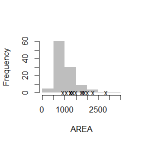

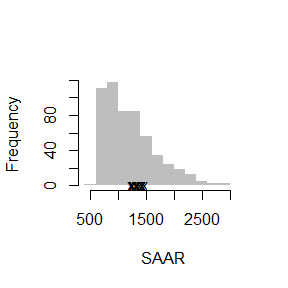

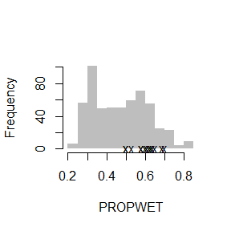

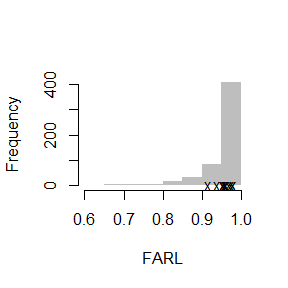

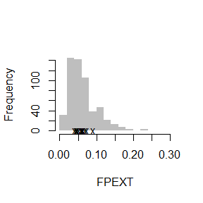

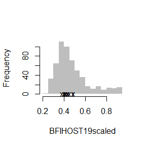

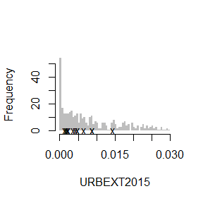

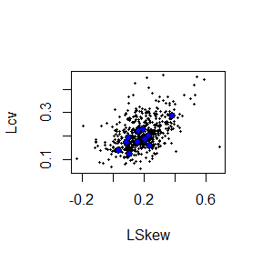

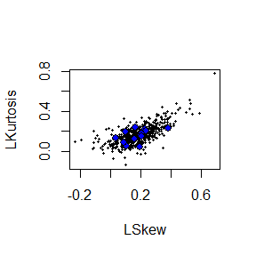

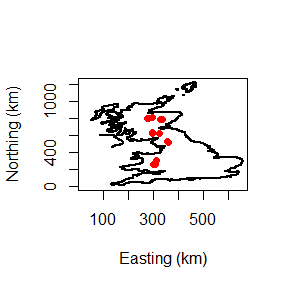

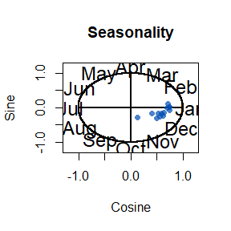

```r
# Create diagnostic plots to aid review of the pooling group
DiagPlots(Pool.55002)
```

```r
# Recreate the pooling group, excluding NRFA sites 8010 and 76017
Pool.55002 <- Pool(CDs = CDs.55002, exclude = c(8010, 76017))

# View the new pooling group
Pool.55002
```

```
#>         AREA SAAR9120 FARL2015  FPEXT BFIHOST19scaled URBEXT2015       Lcv
#> 55002 1894.0     1328   0.9586 0.0693           0.416     0.0049 0.1223836
#> 54005 2027.0     1250   0.9788 0.0919           0.439     0.0090 0.1377923
#> 21006 1506.0     1337   0.9629 0.0443           0.438     0.0043 0.1875159
#> 76007 2276.0     1316   0.9705 0.0741           0.486     0.0145 0.1998481
#> 12002 1833.0     1230   0.9804 0.0483           0.452     0.0024 0.1922955
#> 8006  2852.0     1249   0.9593 0.0525           0.433     0.0023 0.1752581
#> 84003 1093.0     1364   0.9597 0.0645           0.405     0.0067 0.1576754
#> 12001 1380.0     1270   0.9752 0.0468           0.451     0.0015 0.2212125
#> 8005  1261.0     1439   0.9161 0.0589           0.402     0.0018 0.2282631
#> 84018  938.4     1402   0.9544 0.0616           0.400     0.0049 0.1785597
#> 55007 1283.0     1491   0.9544 0.0412           0.381     0.0037 0.1844367
#> 27007  912.6     1223   0.9732 0.0674           0.391     0.0088 0.2021366
#> 21021 3346.0     1169   0.9746 0.0460           0.437     0.0063 0.1656674
#>        LSkew  LKurt QMED  N    SDM Discordancy Discordant
#> 55002 0.1060 0.0466  431 40 0.0000      1.8800      FALSE
#> 54005 0.0354 0.1320  305 73 0.5002      1.9200      FALSE
#> 21006 0.2030 0.1600  397 63 0.5102      0.1480      FALSE
#> 76007 0.2310 0.2190  639 58 0.5294      0.7500      FALSE
#> 12002 0.1000 0.1940  556 53 0.5391      1.2300      FALSE
#> 8006  0.1590 0.1220  501 73 0.5418      0.0531      FALSE
#> 84003 0.2370 0.1980  280 70 0.5668      1.5600      FALSE
#> 12001 0.1640 0.2390  449 96 0.5942      1.6000      FALSE
#> 8005  0.1980 0.0438  173 74 0.6524      2.3100      FALSE
#> 84018 0.2100 0.1770  248 57 0.7404      0.3420      FALSE
#> 55007 0.2090 0.1450  518 85 0.7462      0.2280      FALSE
#> 27007 0.1710 0.0694  278 55 0.8078      0.8500      FALSE
#> 21021 0.1370 0.1400  759 56 0.8146      0.1260      FALSE
```

```r
# Check for heterogeneity
H2(Pool.55002)
```

```
#> [1] "0.236"               "Group is homogenous"
```

### Choosing a distribution.

Once you are happy with the pooling group, you can check for the best distribution. The `Zdists()` function can be used to do this. This compares the Generalised Extreme Value (GEV), Generalised logistic (GenLog), Gumbel, and Kappa3 distributions. The method behind it is outlined in Hosking and Wallis (1997). Note that it is not the same as the method detailed in Science Report SC050050 (Kjeldsen *et al*., 2008). The difference is described in the function’s help file and is necessary to encompass the two-parameter Gumbel distribution.

```r
# Calculate goodness-of-fit measure
Zdists(Pool.55002)
```

```
#> [[1]]
#>      GEV GenLog  Gumbel Kappa3
#> 1 0.0614  -2.43 0.00482  -1.82
#>
#> [[2]]
#> [1] "Gumbel has the best fit"
```

The output is a list, where the first element contains the Z-scores for each distribution, and the second element states which distribution has the best fit.

The L-CV and L-skew for each site are provided in the pooling group and are derived from the AMAX data. If the user has further information, for example, an extra year of data to provide a new annual maximum, the L-CV and L-skew can be calculated using the `Lcv()` & `LSkew()` functions. The user’s data can be pasted in or read into the ‘R’ environment. Data can be read in using a function such as `read.csv()`, or a column of data can be pasted in from Excel by running the following code and then pressing “Ctrl+V” in the console (assuming you have already copied the required data):

```r
MyData <- scan()
```

This creates a numeric vector called `MyData` that contains your flow data. The `Lcv()` & `LSkew()` functions take a numeric vector of flows as their only input, so you can then use `Lcv(MyData)` and `LSkew(MyData)` to derive the L-moment ratios.

The relevant results can be updated in the pooling group by applying the `LRatioChange()` function. For example, if you wanted a new pooling group with updated L-moment ratios for site 55002, the following code could be used:

```r
# Update the pooling group to use user-supplied L-CV and L-skew values for site 55002
UpdatedPool <- LRatioChange(Pool.55002, SiteID = 55002, lcv = 0.187, lskew = 0.164)

# View the updated pooling group
UpdatedPool
```

```
#>         AREA SAAR9120 FARL2015  FPEXT BFIHOST19scaled URBEXT2015       Lcv
#> 55002 1894.0     1328   0.9586 0.0693           0.416     0.0049 0.1870000
#> 54005 2027.0     1250   0.9788 0.0919           0.439     0.0090 0.1377923
#> 21006 1506.0     1337   0.9629 0.0443           0.438     0.0043 0.1875159
#> 76007 2276.0     1316   0.9705 0.0741           0.486     0.0145 0.1998481
#> 12002 1833.0     1230   0.9804 0.0483           0.452     0.0024 0.1922955
#> 8006  2852.0     1249   0.9593 0.0525           0.433     0.0023 0.1752581
#> 84003 1093.0     1364   0.9597 0.0645           0.405     0.0067 0.1576754
#> 12001 1380.0     1270   0.9752 0.0468           0.451     0.0015 0.2212125
#> 8005  1261.0     1439   0.9161 0.0589           0.402     0.0018 0.2282631
#> 84018  938.4     1402   0.9544 0.0616           0.400     0.0049 0.1785597
#> 55007 1283.0     1491   0.9544 0.0412           0.381     0.0037 0.1844367
#> 27007  912.6     1223   0.9732 0.0674           0.391     0.0088 0.2021366
#> 21021 3346.0     1169   0.9746 0.0460           0.437     0.0063 0.1656674
#>        LSkew  LKurt QMED  N    SDM Discordancy Discordant
#> 55002 0.1640 0.0466  431 40 0.0000      1.8800      FALSE
#> 54005 0.0354 0.1320  305 73 0.5002      1.9200      FALSE
#> 21006 0.2030 0.1600  397 63 0.5102      0.1480      FALSE
#> 76007 0.2310 0.2190  639 58 0.5294      0.7500      FALSE
#> 12002 0.1000 0.1940  556 53 0.5391      1.2300      FALSE
#> 8006  0.1590 0.1220  501 73 0.5418      0.0531      FALSE
#> 84003 0.2370 0.1980  280 70 0.5668      1.5600      FALSE
#> 12001 0.1640 0.2390  449 96 0.5942      1.6000      FALSE
#> 8005  0.1980 0.0438  173 74 0.6524      2.3100      FALSE
#> 84018 0.2100 0.1770  248 57 0.7404      0.3420      FALSE
#> 55007 0.2090 0.1450  518 85 0.7462      0.2280      FALSE
#> 27007 0.1710 0.0694  278 55 0.8078      0.8500      FALSE
#> 21021 0.1370 0.1400  759 56 0.8146      0.1260      FALSE
```

## Final estimates (the growth curve and results)

To derive the final estimates, the `PoolEst()` function can be applied to the pooling group. It is necessary to provide an input for the `QMED` argument. Therefore, we will first obtain a QMED estimate (in this case, we will use the data available from the NRFA). To estimate QMED, we can either use the `GetAM()` function and assess the data manually, or we can get it more directly from the `PeakFlowData` data frame embedded within the package (these are calculated as the median of the AMAX data (rejected years excluded) from the NRFA Peak Flow Dataset). The following code provides the latter.

```r
# Extract QMED from the QMEDdata data frame within the UKFE package
GetQMED(55002)
```

```
#> [1] 431
```

We can use functions within functions so we can include the above in `PoolEst()` (two things to note; we need to include the CDs and the Gauged = TRUE argument only impacts the uncertainty calculation):

```r
# Derive the growth curve and final flow estimates based on the pooling group and QMED
PoolEst(Pool.55002, CDs = CDs.55002, QMED = GetQMED(55002), Gauged = TRUE)
```

```
#> $Results
#>      RP    Q   GF    FSE
#> 1     2  431 1.00 1.0566
#> 2     5  551 1.28 1.0575
#> 3    10  634 1.47 1.0593
#> 4    20  721 1.67 1.0622
#> 5    30  775 1.80 1.0645
#> 6    50  848 1.97 1.0681
#> 7    75  909 2.11 1.0715
#> 8   100  955 2.22 1.0742
#> 9   200 1070 2.49 1.0817
#> 10  500 1250 2.90 1.0936
#> 11 1000 1400 3.26 1.1040
#>
#> $`Weighted Lmoment Ratios`
#>         LCV     LSKEW
#> 1 0.1783029 0.1597084
#>
#> $`Distribution Parameters`
#>        loc    scale     shape
#> 1 430.7645 77.56144 -0.157633
```

The results are printed to the console. This is a list with three elements. The first is a data frame with the following columns: return period (RP), peak flow estimates (Q), growth factor estimates (GF), and factorial standard error. The latter is calculating by bootstrapping the pooling group and sampling from the QMED uncertainty. The second element is the estimated pooled L-CV and L-skew (linear coefficients of variation and skewness). The third element provide parameters (location, scale, and, shape) for the chosen distribution.

The user should be aware of the following specifics about how UKFE employs the pooled method:

- The default QMED FSE is set to 1.5. This value represents the factorial standard error associated with the combined model and sampling uncertainty of the QMED model. You can update QMED FSE with the fseQMED argument. Generally it should be lower if donor catchments are applied or if the QMED is estimated from a gauged sample.
- The default distribution applied is the generalised logistic distribution.
- The final FSE comprises the FSE associated with QMED estimation and growth curve estimation. The FSE associated with the growth curve quantifies sampling error (aleatoric uncertainty) only. The FSE associated with QMED includes model uncertainty. In general, the uncertainty associated with the modelling process or the hydrometric data collection is not included in the FSE. Many choices are made during the process, and deriving a range of results from a range of justifiable choices is a way to quantify some of the epistemic uncertainty.
- By default, urban adjustment is applied. The user can change this with the `UrbAdj` argument, by setting it to `FALSE`.

The `EVPool()` function can be used to plot a growth curve.

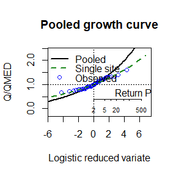

```r
# Plot the growth curve
EVPool(Pool.55002, gauged = TRUE)
```

For the **ungauged catchment**, the same process can be followed. First, we’ll exclude the site from our pooling group. We will assume we went through a rigorous pooling group analysis and concluded all was well:

```r
# Recreate the pooling group, excluding NRFA gauge 55002 to make it an ungauged analysis
PoolUG.55002 <- Pool(CDs.55002, exclude = 55002)

# View the new pooling group
PoolUG.55002
```

```
#>         AREA SAAR9120 FARL2015  FPEXT BFIHOST19scaled URBEXT2015       Lcv
#> 8010  1746.0     1342   0.9377 0.0612           0.415     0.0019 0.1742120
#> 54005 2027.0     1250   0.9788 0.0919           0.439     0.0090 0.1377923
#> 21006 1506.0     1337   0.9629 0.0443           0.438     0.0043 0.1875159
#> 76007 2276.0     1316   0.9705 0.0741           0.486     0.0145 0.1998481
#> 12002 1833.0     1230   0.9804 0.0483           0.452     0.0024 0.1922955
#> 8006  2852.0     1249   0.9593 0.0525           0.433     0.0023 0.1752581
#> 84003 1093.0     1364   0.9597 0.0645           0.405     0.0067 0.1576754
#> 12001 1380.0     1270   0.9752 0.0468           0.451     0.0015 0.2212125
#> 76017 1372.0     1430   0.9536 0.0615           0.488     0.0090 0.2866483
#> 8005  1261.0     1439   0.9161 0.0589           0.402     0.0018 0.2282631
#> 84018  938.4     1402   0.9544 0.0616           0.400     0.0049 0.1785597
#> 55007 1283.0     1491   0.9544 0.0412           0.381     0.0037 0.1844367
#> 27007  912.6     1223   0.9732 0.0674           0.391     0.0088 0.2021366
#>        LSkew  LKurt QMED  N    SDM Discordancy Discordant
#> 8010  0.0897 0.0897  241 73 0.2628       0.640      FALSE
#> 54005 0.0354 0.1320  305 73 0.5002       1.220      FALSE
#> 21006 0.2030 0.1600  397 63 0.5102       0.106      FALSE
#> 76007 0.2310 0.2190  639 58 0.5294       0.425      FALSE
#> 12002 0.1000 0.1940  556 53 0.5391       1.210      FALSE
#> 8006  0.1590 0.1220  501 73 0.5418       0.187      FALSE
#> 84003 0.2370 0.1980  280 70 0.5668       1.710      FALSE
#> 12001 0.1640 0.2390  449 96 0.5942       1.690      FALSE
#> 76017 0.3820 0.2300  482 23 0.6298       2.550      FALSE
#> 8005  0.1980 0.0438  173 74 0.6524       1.860      FALSE
#> 84018 0.2100 0.1770  248 57 0.7404       0.352      FALSE
#> 55007 0.2090 0.1450  518 85 0.7462       0.250      FALSE
#> 27007 0.1710 0.0694  278 55 0.8078       0.797      FALSE
```

```r
# Estimate QMED from the catchment descriptors with two donors (note that the QMED
# value needs to be extracted using `$QMEDs.adj` as there are three elements to the
# output when two donors are used and the PoolEst function expects just the QMED value)
CDsQmed.55002 <- QMED(CDs.55002, DonorIDs = c(55007, 55016))

# Use the pooling group and the ungauged QMED estimate to provide the pooled estimates
Results55002 <- PoolEst(PoolUG.55002, QMED = CDsQmed.55002, CDs = CDs.55002)

# Print the results
Results55002
```

```
#> $Results
#>      RP    Q   GF    FSE
#> 1     2  545 1.00 1.5000
#> 2     5  707 1.30 1.5062
#> 3    10  822 1.51 1.5178
#> 4    20  943 1.73 1.5353
#> 5    30 1020 1.87 1.5485
#> 6    50 1120 2.06 1.5686
#> 7    75 1210 2.22 1.5874
#> 8   100 1270 2.34 1.6022
#> 9   200 1450 2.65 1.6436
#> 10  500 1710 3.13 1.7104
#> 11 1000 1930 3.54 1.7704
#>
#> $`Weighted Lmoment Ratios`
#>        LCV     LSKEW
#> 1 0.189032 0.1745905
#>
#> $`Distribution Parameters`
#>       loc    scale      shape
#> 1 539.716 105.2853 -0.1713254
```

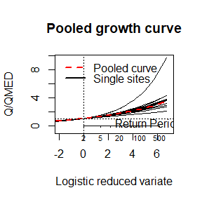

```r
# Plot a growth curve for the pooling group
EVPool(PoolUG.55002)
```

The same results are provided as for the gauged case.